# Gitting Started: Git and GitLab

October 5, 2015

## Version Control and Code Review

## Version Control

**Who Wrote What When and Why**

A version control system tracks changes to files over time.

VCS is like Track Changes, but better. It's designed for multiple users working on the same material simultaneously and for selectively rolling back changes. We can go back in time and retrieve the state of our code before changes were introduced.

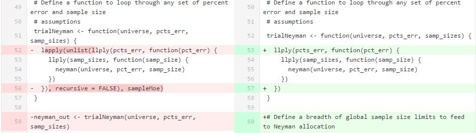

## Code Review

**"Efficient streamlined QC" is not an oxymoron.**

Code review integrates quality control, and its documentation, into the workflow.

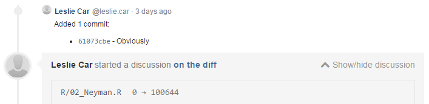

## Git and GitLab

## Git is…

- Version control
  - authorship, time stamps, and files changed
- Distributed
  - Repositories are self-contained and collaborative - work on a flight and share when you land.
- Open source and widely used

[figure not shown]

## GitLab is…

- Code review
- Browser-based Git repository manager
- Project ownership and management
- Task assignment and tracking
- Open source and widely used

[figure not shown]

## Git

## Install Git

http://git-scm.com/downloads

(Windows) With Git installed, you should be able to right-click in any folder and select "Git Bash Here" to pull up a console.

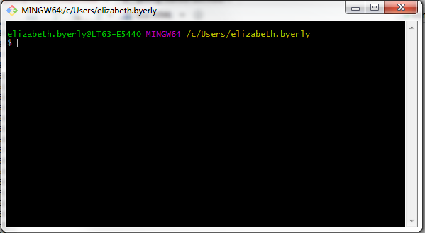

All commands to Git are issued through the console, or [command line interface](https://en.wikipedia.org/wiki/Command-line_interface).

## Configure Git

```bash
git config --global user.name "Elizabeth Byerly"
git config --global user.email "elizabeth.byerly@gmail.com"
```

By issuing these configuration commands, all our Git activity will be stamped with our name and e-mail.

These commands must be re-issued for every installation of Git (i.e., if you want to use Git on your home computer).

## Create a Git repository

We use the `init` command to create a repository in the current [working directory](https://en.wikipedia.org/wiki/Working_directory) of our console.

```bash
git init
```

Or, we can specify the directory we want to make a Git repository (it will make the directory if it does not exist).

```bash
git init "L:/my-new-project"
```

All files in the working directory, as well as all files in all subfolders, will be seen by Git.

## Making and committing changes

Add some files to your directory and then to your new git repository.

```bash
git status
git add --all
git status
git commit -m 'My first commit'
git status
```

`status` is helpful for seeing the current condition of your potential `commit`. The first call will show in red the files you've added to your repo. The second call will show them in green, staged and ready to be tracked by Git. The last call, after our commit, shows we have no current changes to consider.

## Seen, Staged, Committed

Let's pause here to talk about three levels of "saved" in the world of Git:

- Seen: Files written to disk, our **working copy**. Git cannot see work in our file editor until we save it. (We can also deliberately hide files from Git using [`.gitignore`](https://git-scm.com/docs/gitignore).)
- Staged: Git is aware of a change and is ready to add it to the file's tracked history.
- Committed: Git has saved the state of the staged file changes written to disk.

We care about **committed** file changes. Changes saved to disk and staged, but never committed, can be lost as soon as we change the file again.

## Commit history

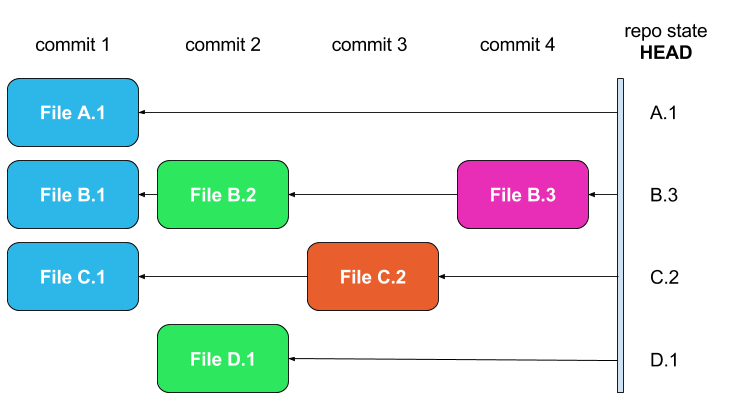

## Change a file

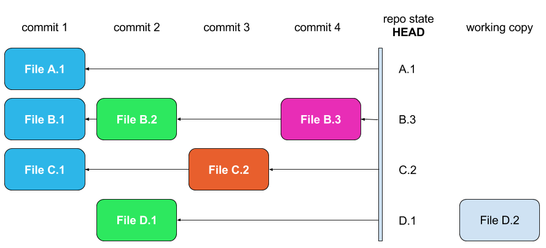

## Stage a file

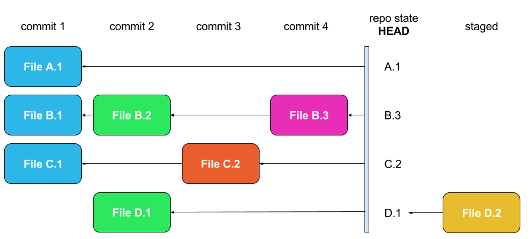

## Commit, update repo history

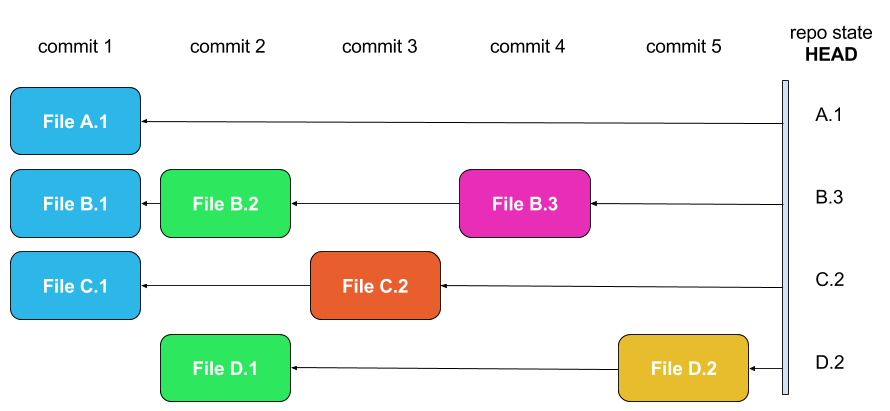

## Checkout

```bash
git checkout <commit hash 1> "File C"
```

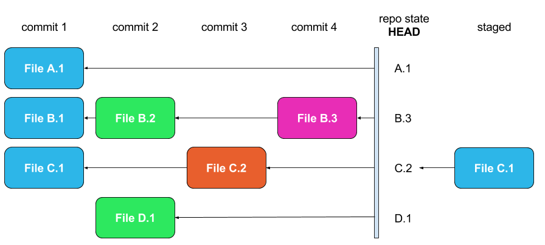

```bash
git checkout HEAD@{3} "File C"
```

## Branching

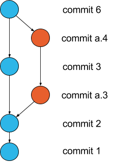

```bash
git checkout -b dev
```

When collaborating, branching allows us to work from a stable base while continuing to commit our interim work.

Once our updates are ready, we can merge them onto the `master` (or any other) branch.

```bash
git checkout master
git merge dev
```

## Cloning

Repositories can be cloned.

```bash
git clone -b master "L:/my-new-project" "P:/my-clone-new-project"
```

Note we provide the option `-b master`, which specifies we want to clone the master branch initially. All branches pushed to the central repository are available; this option sets what you define as your local `master`.

## Fourth level saving: central

Updating based on the changes in `origin` is one part of Git's collaborative workflow. To be able to `push` our changes to origin (that is, update `origin` based on the changes we make to our `remote` repository), we need to make `origin` a `bare` repository.

What is a bare repository? One without a working directory!

For collaborative workflows, this is key. Multiple users can use a bare repository as their `central` repository - the one source of project Truth - from which they will `pull` down changes and `push` updates.

## Bare repositories, cloning, pulling

```bash
git init --bare "L:/second-new-project"
git clone "L:/second-new-project" "P:/my-remote-second-project"
```

We do some work, add some files changes, then *we check the `origin` repo is in the same state as when we cloned*.

```bash
git pull origin
```

If changes were introduced by another collaborator, they either (a) merge without issue or (b) introduce code conflicts we can resolve.

## Pushing

Finally, we give our code changes to the `central` repository.

```bash
git push origin master
```

Note, if we skipped the `git pull` step and another contributer has added conflicting work to the project, your `push` will be rejected!

Otherwise, anyone with access to the bare `central` repository can now clone our work and add to it.

## Git GUIs

- Git GUI for Windows (`gitk`)
- SourceTree
- Giggle
- …many more!
- *Note: TortoiseGit will break our Windows SSH connection to GitLab.*

These have not been reviewed for compatibility with a GitLab workflow. Please provide feedback if any of these are particularly easy/difficult or effective/horrible to use.

## GitLab

## Make your account

https://gitlab.com/users/sign_in

Follow the instructions! I believe in you.

## Attach an SSH key to your account

In your console window, run the SSH generation.

```bash
ssh-keygen -t rsa -C "elizabeth.byerly@gmail.com"
```

Allow its default save location and press `Enter` twice to create without a password. Then, copy your public key to your clipboard.

```bash
clip < "~/.ssh/id_rsa.pub"
```

Paste the contents of your clipboard into **Add an SSH Key**: https://gitlab.com/profile/keys

These commands must be re-issued for every computer on which you use GitLab. You can add multiple SSH keys to your GitLab account.

## Make your first project

https://gitlab.com/projects/new

Your **Project path** is your project name. It cannot contain spaces.

Your **Visibility Level** sets the project privacy.

- Private: Your project is invisible to users not explicitly invited to see it. Authentication is required to read and write. (This option is only available for private installations of GitLab.)
- Internal: Your project is visible to users logged into https://gitlab.com/. Authentication is required to write.
- Public: Your project is visible to everyone and can be copied by anyone.

We can also **Create a group** if we want to associate multiple projects.

## Clone your project

```bash
git clone git@gitlab.com:ByerlyElizabeth/test-gitlab.git
```

Once you've cloned the bare repository from GitLab, you use it exactly the same as a normal Git repository. The `push` and `pull` commands will refer to the bare repository on the GitLab server.

## Add users

https://gitlab.com/ByerlyElizabeth/test-gitlab/project_members

When adding a user to your project, you must assign their [permissions](https://gitlab.com/gitlab-org/gitlab-ce/blob/master/doc/permissions/permissions.md) level.

- Owner: Creator of the project. Can delete or change the visibility level.
- Master: Create milestones, add team members, and push to protected branches.
- Developer: Create and manage merge requests, create and modify unprotected branches.
- Reporter: Pull code and manage issues.
- Guest: Create issues and leave comments.

## Issues

https://gitlab.com/ByerlyElizabeth/test-gitlab/issues

Issues can be assigned to a user on the project or be left unassigned. They can also be associated with a milestone and labels.

Milestones are for documentation purposes.

[figure not shown]

## Protected branches

By default, the `master` branch is [protected](http://doc.gitlab.com/ce/workflow/protected_branches.html).

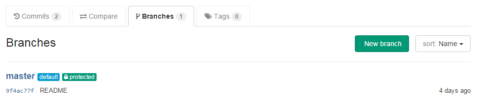

Protected branches can only be written to by users with **Master** or **Owner** [permissions](https://gitlab.com/gitlab-org/gitlab-ce/blob/master/doc/permissions/permissions.md). This forces lower level users to issue a **merge request**.

## Merge requests

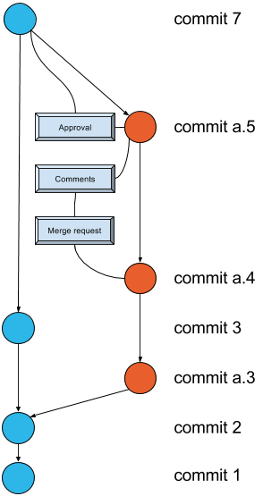

Before a development branch can be merged onto a protected branch, it must pass through a **merge request**. Merge requests are a formal process of code review and approval.

Once the request is approved, the work is added to the `master` branch as a new known stable release.

## View the update history

https://gitlab.com/ByerlyElizabeth/test-gitlab/network/master

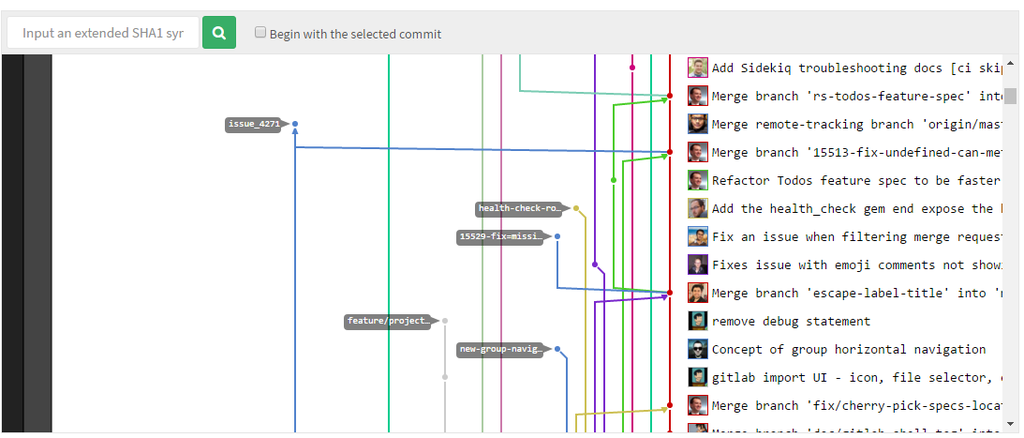